# MPI Sweep (real) — corner reconstruction: 10x10 vs. 33x33 vs. flood

The real counterpart of `MPIsweep.ipynb`: the same concave corner (vertical fold) measured with the Schmersal AM-T100, once per illumination:

| set | VCSEL | delay (coarse/fine/superfine) | exposure |
| --- | --- | --- | --- |
| `10x10` | 5 (10x10 DOE) | 7 / 0 / 5 | 100 µs |
| `33x33` | 6 (coherent 33x33) | 0 / 0 / 0 | 100 µs |
| `Flood` | 4 (flood) | 7 / 0 / 5 | 1000 µs |

The corners are labelled by their **inner angle**. The real target could not reproduce the simulated angles exactly, so the angles differ from `MPIsweep.ipynb`, and there is only one fold distance per measurement series. Corner and camera did not move between the three illuminations of one angle. Two series, selected with `MEAS_ROOT`:

| series | fold distance | inner angles |
| --- | --- | --- |
| `MPI_Messung_07.10/` | ≈ 1.3 m | 45°, 60°, 90° (outputs archived in `MPI_sweep_real_1.3m.html`) |
| `MPI_Messung_07.10/MPI_1m_WW/` | ≈ 1 m | 30°, 45°, 60°, 90° |

Data: `<MEAS_ROOT>/<date>_<time>_<pattern>_<angle>/ToF_RAW/frame_*.npy`, 10 frames per set, AandB (8 tap images per frame), 100 MHz. The notebook turns the RAWs into an organised PCD + an intensity EXR per set (step 1) — by default from the **first frame** of every set (`FRAME_MODE`), as the calibration also used single frames. Then it runs Approach 1/2/3 with the existing real calibrations, fits the ground-truth corner from the data, and draws the plots of `MPIsweep.ipynb`. All heavy lifting lives in `dot_calibration.py`, `approaches.py` and `itofcameracalibration/tof_processing`; this notebook only orchestrates and plots.

```python
from dot_calibration import DotCalibration
import approaches
import calibrate
import contextlib
import io
import os
import re
import sys
import numpy as np
from pathlib import Path
os.environ["OPENCV_IO_ENABLE_OPENEXR"] = "1"
import matplotlib.pyplot as plt
import logging
from scipy.ndimage import map_coordinates
import warnings
from sklearn.exceptions import ConvergenceWarning
warnings.filterwarnings("ignore", category=ConvergenceWarning)   # GPR subpixel fits, harmless
logging.getLogger("matplotlib.axes._base").setLevel(logging.ERROR)   # "Ignoring fixed x limits …" (equal aspect)

dotCal = DotCalibration()

# ── Data locations ──────────────────────────────────────────────────────────
MEAS_ROOT     = Path("/home/julian/Documents/Calibrations/MPI_Messung_07.10")             # fold ≈ 1.3 m, 45/60/90°
ITOF_CAL_REPO = Path("/home/julian/Documents/Calibrations/itofcameracalibration")   # tof_processing (read-only)
HDF5_ROOT     = Path("/home/julian/Documents/Calibrations")
ANGLES        = (30, 45, 60, 90)      # inner angle of the corner [deg]; incomplete angles are skipped
PATTERNS      = {"10x10": dict(label="10x10"), "33x33": dict(label="33x33")}
FLOOD         = "Flood"

# Depth calibration per pattern. It has to match the one the dot calibration's PCDs were made
# with — otherwise the ToF range is off by a constant per VCSEL/delay setting (see step 1):
#   10x10 (25.08, delay 7/0/5)    → CalibData_Julian.hdf5        (Pos3: 530 mm vs. 532 mm in the PCD)
#   33x33 (30.09, delay 0/0/0)    → CalibData_Julian_LensOnly.hdf5 (Pos3: 575 mm vs. 573 mm)
#   Flood (delay 7/0/5, like 10x10) → CalibData_Julian.hdf5
HDF5 = {"10x10": HDF5_ROOT / "CalibData_Julian.hdf5",
        "33x33": HDF5_ROOT / "CalibData_Julian_LensOnly.hdf5",
        FLOOD:   HDF5_ROOT / "CalibData_Julian.hdf5"}

# Settings every set must have been recorded with (taken from the calibration sessions).
REF_SETTINGS = {"10x10": dict(ActiveVcsel=0b010000, DelayCoarse=7, DelayFine=0, DelaySuperFine=5, ExposureTime=100),
                "33x33": dict(ActiveVcsel=0b100000, DelayCoarse=0, DelayFine=0, DelaySuperFine=0, ExposureTime=100),
                FLOOD:   dict(ActiveVcsel=0b001000, DelayCoarse=7, DelayFine=0, DelaySuperFine=5, ExposureTime=1000)}

# Existing real calibrations (codePaperlike), no recalibration here.
#   "corr13456": iToF_SL_fusion_pipeline.ipynb with the 6-stage ToF error model (stages 1–6 on);
#                the test clouds get the same model (cell "ToF error model" below)
#   "lpc":       the earlier calibrations, light-path correction only
CAL_VARIANT = "corr13456"
CAL_ROOT = Path.cwd().parent / "Calibrations"
CAL_SETS = {
    "corr13456": {"10x10": "SchmersalReal_paperlike_sor6-0.40_lpc_corr13456_06.10_",
                  "33x33": "SchmersalRealCoherent_paperlike_sor6-0.40_lpc_corr13456_06.10_CoherentLens"},
    "lpc":       {"10x10": "SchmersalReal_paperlike_sor6-0.40_lpc_06.10",
                  "33x33": "SchmersalRealCoherent_paperlike_sor6-0.40_lpc_06.10_CoherentLens"},
}
CAL_FILES = {pat: CAL_ROOT / name / "calibration.json" for pat, name in CAL_SETS[CAL_VARIANT].items()}
# Wall measurement the error model of each pattern is fitted on (keys of WALL_SETS below).
ERR_CAMERA = {"10x10": "SchmersalReal", "33x33": "SchmersalRealCoherent"}

F_MOD          = 100                  # [MHz]
UNAMBIGUITY    = 299792458.0 / (2 * F_MOD * 1e6)   # [m] 1.499 m
Z_MAX          = 1.45                 # [m] keep clear of the phase wrap
FRAME_MODE     = "first"              # "first": first RAW frame of every set | "avg": 10-frame average
WRITE_FRAMES   = False                # "avg" only: also write every single frame as PCD + EXR

CACHE_DIR   = Path.cwd().parent / "Results" / "mpi_sweep_real"
FORCE_RERUN = False                   # True → redo RAW conversion and sweep, ignore caches
CACHE_DIR.mkdir(parents=True, exist_ok=True)

if str(ITOF_CAL_REPO) not in sys.path:
    sys.path.insert(0, str(ITOF_CAL_REPO))
from tof_processing.tof_processing import tof_pipeline, parse_DeltaRawData

approaches.GT_DISTANCE = None         # no single GT distance in a corner scene
print("Setup complete.")
```

```
Setup complete.
```

## Measurement sets

Every folder `<date>_<time>_<pattern>_<angle>` is one set; if a (pattern, angle) was recorded more than once, the newest folder wins. The camera YAML stored next to the RAWs is checked against the settings of the calibration sessions (VCSEL, delays, exposure) — a mismatch is printed as a warning, because a different delay shifts the ToF range by a constant (≈ 0.2–0.6 m here).

```python
SET_RE = re.compile(r"^(\d{4}-\d{2}-\d{2}_\d{2}-\d{2}-\d{2})_(10x10|33x33|Flood)_(\d+)$")
YAML_KEYS = ("ActiveVcsel", "DelayCoarse", "DelayFine", "DelaySuperFine", "ExposureTime",
             "Frequency", "SensorOutputMode", "CustomVcselPower", "calibrationFile")


def read_camera_yaml(set_dir):
    # The camera YAML holds binary literals (0b010000) and comments → read the keys by regex.
    out = {}
    for y in Path(set_dir).glob("*.yaml"):
        txt = re.sub(r"#.*", "", y.read_text())
        for k in YAML_KEYS:
            m = re.search(rf"^\s*{k}\s*:\s*\"?([^\"\n]+?)\"?\s*$", txt, re.M)
            if m:
                v = m.group(1).strip()
                out[k] = int(v, 0) if re.fullmatch(r"0b[01]+|\d+", v) else v
    return out


SETS = {}
for d in sorted(MEAS_ROOT.iterdir()):
    m = SET_RE.match(d.name)
    if not (d.is_dir() and m):
        continue
    stamp, pat, angle = m.group(1), m.group(2), int(m.group(3))
    frames = sorted((d / "ToF_RAW").glob("frame_*.npy"))
    if not frames:
        print(f"skip {d.name}: no RAW frames")
        continue
    if (pat, angle) in SETS:
        print(f"{pat} {angle}°: {SETS[(pat, angle)]['dir'].name} replaced by the newer {d.name}")
    SETS[(pat, angle)] = dict(dir=d, frames=frames, yaml=read_camera_yaml(d))

print(f"{'set':34s} {'frames':>6s}  VCSEL     delay   exp[µs]  power  mode    calibrationFile")
for (pat, angle), s in sorted(SETS.items(), key=lambda kv: (kv[0][1], kv[0][0])):
    y = s["yaml"]
    print(f"{s['dir'].name:34s} {len(s['frames']):6d}  {y.get('ActiveVcsel', 0):#08b}  "
          f"{y.get('DelayCoarse')}/{y.get('DelayFine')}/{y.get('DelaySuperFine')}  "
          f"{y.get('ExposureTime'):>7}  {y.get('CustomVcselPower'):>5}  {y.get('SensorOutputMode'):6s}  "
          f"{y.get('calibrationFile')}")
    bad = {k: (y.get(k), v) for k, v in REF_SETTINGS[pat].items() if y.get(k) != v}
    if bad or y.get("SensorOutputMode") != "AandB":
        print(f"    WARNING {pat} {angle}°: differs from the calibration session: "
              + ", ".join(f"{k} {a} (ref {b})" for k, (a, b) in bad.items()))

ANGLES = tuple(a for a in ANGLES if all((p, a) in SETS for p in list(PATTERNS) + [FLOOD]))
print(f"\ncomplete corners (10x10 + 33x33 + flood): {ANGLES}")
```

```
set                                frames  VCSEL     delay   exp[µs]  power  mode    calibrationFile
2026-10-07_12-02-00_10x10_45           10  0b010000  7/0/5      100   1500  AandB   utils/CalibData_Julian_LensOnly.hdf5
2026-10-07_12-00-24_33x33_45           10  0b100000  0/0/0      100   1260  AandB   utils/CalibData_Julian_LensOnly.hdf5
2026-10-07_12-03-23_Flood_45           10  0b001000  7/0/5     1000   1500  AandB   utils/CalibData_Julian_LensOnly.hdf5
2026-10-07_11-54-32_10x10_60           10  0b010000  7/0/5      100   1500  AandB   utils/CalibData_Julian_LensOnly.hdf5
2026-10-07_11-58-05_33x33_60           10  0b100000  0/0/0      100   1260  AandB   utils/CalibData_Julian_LensOnly.hdf5
2026-10-07_11-53-07_Flood_60           10  0b001000  7/0/5     1000   1500  AandB   utils/CalibData_Julian_LensOnly.hdf5
2026-10-07_12-15-02_10x10_90           10  0b010000  7/0/5      100   1500  AandB   utils/CalibData_Julian_LensOnly.hdf5
2026-10-07_12-15-58_33x33_90           10  0b100000  0/0/0      100   1260  AandB   utils/CalibData_Julian_LensOnly.hdf5
2026-10-07_12-14-01_Flood_90           10  0b001000  7/0/5     1000   1500  AandB   utils/CalibData_Julian_LensOnly.hdf5

complete corners (10x10 + 33x33 + flood): (45, 60, 90)
```

## Step 1 — RAW → PCD + intensity EXR

Per set, `FRAME_MODE = "first"` takes the first RAW frame (`"avg"`: the 10 frames averaged tap by tap, A and B separately) and it goes through `tof_pipeline` with the HDF5 of its pattern (phase offset, FPPN, wiggling, lens model). The averaged taps are passed as A − B differences (`process_2rad(Diffs=…)`): `process_fromRaw` would cast the averaged taps to int32 and throw away the sub-LSB part that the averaging gained. The intensity (A + B)/2 is `calc_intensity` of the same averaged taps. This is exactly what `binary2pcd.py` writes, just for the new folder layout:

- `<set>/ToF_PCD/<frame>.pcd` (or `avg.pcd`) — organised 640×480, fields `x y z grayValue rad distZ` [mm]
- `<set>/SL/<frame>.exr` (or `avg.exr`) — intensity in channel `S0.940,000nm` (like `pcdToExr.py`), the SL image of the approaches

The pixel rays `(x/z, y/z)` of the lens model are kept: the approaches return pixel + axial depth, and turning that into x, y with the same rays as the clouds keeps dots and flood in one frame.

```python
import OpenEXR
import Imath

PIPES = {str(h): tof_pipeline(fMod=F_MOD, height=480, width=640, calibrationFile=str(h))
         for h in sorted(set(map(str, HDF5.values())))}


def pipe_rays(pipe):
    # Lens-model rays: X = Z·rx, Y = Z·ry (tof_pipeline.calc_XfromZ / calc_YfromZ).
    rx = (pipe.lens_u_corr - pipe.lens_c_mtx[0, 2]) / pipe.lens_c_mtx[0, 0]
    ry = (pipe.lens_v_corr - pipe.lens_c_mtx[1, 2]) / pipe.lens_c_mtx[1, 1]
    return np.asarray(rx, float), np.asarray(ry, float)


def process_raw(pipe, raw):
    # One AandB frame (single or averaged) → X, Y, Z, rad, intensity [mm / LSB].
    A, B = parse_DeltaRawData(raw)
    A, B = np.asarray(A, np.float64), np.asarray(B, np.float64)
    pipe.process_2rad(Diffs=list(A - B))
    pipe.intensity = pipe.calc_intensity(A, B)
    pipe.calc_XYZ()
    return [np.asarray(a, np.float64) for a in (pipe.X, pipe.Y, pipe.Z, pipe.radDist, pipe.intensity)]


def write_pcd(path, X, Y, Z, gray, rad):
    fields = ("x", "y", "z", "grayValue", "rad", "distZ")
    data = np.empty(X.size, dtype=[(f, "<f8") for f in fields])
    for f, a in zip(fields, (X, Y, Z, gray, rad, Z)):
        data[f] = np.asarray(a, np.float64).ravel()
    H, W = X.shape
    header = ("# .PCD v.7 - Point Cloud Data file format\nVERSION .7\n"
              f"FIELDS {' '.join(fields)}\nSIZE {' '.join(['8'] * 6)}\nTYPE {' '.join(['F'] * 6)}\n"
              f"COUNT {' '.join(['1'] * 6)}\nWIDTH {W}\nHEIGHT {H}\nVIEWPOINT 0 0 0 1 0 0 0\n"
              f"POINTS {X.size}\nDATA binary\n")
    path.parent.mkdir(parents=True, exist_ok=True)
    with open(path, "wb") as f:
        f.write(header.encode("ascii"))
        f.write(data.tobytes())


def write_exr(path, img):
    h, w = img.shape
    header = OpenEXR.Header(w, h)
    header["channels"] = {dotCal.SL_CHANNEL: Imath.Channel(Imath.PixelType(Imath.PixelType.FLOAT))}
    path.parent.mkdir(parents=True, exist_ok=True)
    out = OpenEXR.OutputFile(str(path), header)
    out.writePixels({dotCal.SL_CHANNEL: np.ascontiguousarray(img, np.float32).tobytes()})
    out.close()


def convert_set(pat, s):
    name = s["frames"][0].stem if FRAME_MODE == "first" else "avg"
    pcd, exr = s["dir"] / "ToF_PCD" / f"{name}.pcd", s["dir"] / "SL" / f"{name}.exr"
    s.update(pcd=pcd, exr=exr, frame=name)
    if pcd.exists() and exr.exists() and not FORCE_RERUN:
        return False
    pipe = PIPES[str(HDF5[pat])]
    if FRAME_MODE == "first":
        X, Y, Z, rad, inten = process_raw(pipe, np.load(s["frames"][0]).astype(np.float64))
        write_pcd(pcd, X, Y, Z, inten, rad)
        write_exr(exr, inten)
        return True
    raws = np.array([np.load(f).astype(np.float64) for f in s["frames"]])
    X, Y, Z, rad, inten = process_raw(pipe, raws.mean(axis=0))
    write_pcd(pcd, X, Y, Z, inten, rad)
    write_exr(exr, inten)
    if WRITE_FRAMES:
        for f, raw in zip(s["frames"], raws):
            X, Y, Z, rad, inten = process_raw(pipe, raw)
            write_pcd(s["dir"] / "ToF_PCD" / f"{f.stem}.pcd", X, Y, Z, inten, rad)
            write_exr(s["dir"] / "SL" / f"{f.stem}.exr", inten)
    return True


for (pat, angle), s in sorted(SETS.items()):
    new = convert_set(pat, s)
    print(f"{s['dir'].name:34s} → ToF_PCD/{s['frame']}.pcd + SL/{s['frame']}.exr  ({'written' if new else 'cached'}, "
          f"{Path(HDF5[pat]).name})")

FRAME_TAG = "_first" if FRAME_MODE == "first" else "_avg"
RAYS = {pat: pipe_rays(PIPES[str(HDF5[pat])]) for pat in list(PATTERNS) + [FLOOD]}
_r = [np.stack(r) for r in RAYS.values()]
print(f"\nlens rays of the two HDF5 files differ by at most "
      f"{max(np.nanmax(np.abs(a - _r[0])) for a in _r) * 505:.4f} px")
```

```
WARNING: 'Models_LUTs/100' not found in calibration file, only the lens calibration is applied.
2026-10-07_12-02-00_10x10_45       → ToF_PCD/frame_000001.pcd + SL/frame_000001.exr  (cached, CalibData_Julian.hdf5)
2026-10-07_11-54-32_10x10_60       → ToF_PCD/frame_000001.pcd + SL/frame_000001.exr  (cached, CalibData_Julian.hdf5)
2026-10-07_12-15-02_10x10_90       → ToF_PCD/frame_000001.pcd + SL/frame_000001.exr  (cached, CalibData_Julian.hdf5)
2026-10-07_12-00-24_33x33_45       → ToF_PCD/frame_000001.pcd + SL/frame_000001.exr  (cached, CalibData_Julian_LensOnly.hdf5)
2026-10-07_11-58-05_33x33_60       → ToF_PCD/frame_000001.pcd + SL/frame_000001.exr  (cached, CalibData_Julian_LensOnly.hdf5)
2026-10-07_12-15-58_33x33_90       → ToF_PCD/frame_000001.pcd + SL/frame_000001.exr  (cached, CalibData_Julian_LensOnly.hdf5)
2026-10-07_12-03-23_Flood_45       → ToF_PCD/frame_000001.pcd + SL/frame_000001.exr  (cached, CalibData_Julian.hdf5)
2026-10-07_11-53-07_Flood_60       → ToF_PCD/frame_000001.pcd + SL/frame_000001.exr  (cached, CalibData_Julian.hdf5)
2026-10-07_12-14-01_Flood_90       → ToF_PCD/frame_000001.pcd + SL/frame_000001.exr  (cached, CalibData_Julian.hdf5)

lens rays of the two HDF5 files differ by at most 0.0000 px
```

### Check: pipeline, intrinsics and raw data

```python
def fit_K_from_pcd(pcd_path):
    t = dotCal.load_tof_pcd(str(pcd_path), unit_scale=0.001, depth_mode="axial")
    P = t["points_map"]
    H, W = P.shape[:2]
    v, u = np.mgrid[0:H, 0:W]
    ok = np.isfinite(P).all(axis=-1)
    x, y, z = P[..., 0][ok], P[..., 1][ok], P[..., 2][ok]
    (fx_, cx_), *_ = np.linalg.lstsq(np.c_[x / z, np.ones_like(x)], u[ok], rcond=None)
    (fy_, cy_), *_ = np.linalg.lstsq(np.c_[y / z, np.ones_like(y)], v[ok], rcond=None)
    return fx_, fy_, cx_, cy_


def frame_noise(pat, s):
    # Range scatter over the single frames [mm] per amplitude bin (circular std of the phase).
    I, Q = [], []
    for f in s["frames"]:
        A, B = (np.asarray(x, float) for x in parse_DeltaRawData(np.load(f).astype(np.float64)))
        D = A - B
        I.append(D[0] - D[2]); Q.append(D[3] - D[1])
    z = np.array(I) + 1j * np.array(Q)
    amp = np.abs(z.mean(axis=0))
    dphi = np.angle(z * np.exp(-1j * np.angle(z.mean(axis=0))))
    sig = np.sqrt(np.mean(dphi ** 2, axis=0)) * UNAMBIGUITY * 1e3 / (2 * np.pi)
    edges = (20, 50, 150, 500, 1e9)
    return [(lo, float(np.median(sig[(amp >= lo) & (amp < hi)])) if ((amp >= lo) & (amp < hi)).sum() > 200 else np.nan)
            for lo, hi in zip(edges[:-1], edges[1:])]


print(f"{'set':34s}  f_x     f_y     c_x    c_y   | σ_range single frame [mm] for amplitude ≥ 20 / 50 / 150 / 500 LSB")
for (pat, angle), s in sorted(SETS.items(), key=lambda kv: (kv[0][1], kv[0][0])):
    fx_, fy_, cx_, cy_ = fit_K_from_pcd(s["pcd"])
    nz = frame_noise(pat, s)
    print(f"{s['dir'].name:34s} {fx_:6.1f}  {fy_:6.1f}  {cx_:6.1f} {cy_:6.1f} | "
          + "  ".join("   –  " if np.isnan(v) else f"{v:6.1f}" for _, v in nz))
if FRAME_MODE == "avg":
    print(f"(10 frames averaged → ≈ ÷{np.sqrt(10):.1f})")
```

```
set                                 f_x     f_y     c_x    c_y   | σ_range single frame [mm] for amplitude ≥ 20 / 50 / 150 / 500 LSB
2026-10-07_12-02-00_10x10_45        494.7   499.7   322.9  242.2 |   15.0     6.0     3.2     –
```

```
2026-10-07_12-00-24_33x33_45        495.1   499.9   323.0  242.2 |   14.8     7.1     4.1     –
2026-10-07_12-03-23_Flood_45        494.4   499.4   322.9  242.2 |   15.9     4.2     2.7     –
```

```
2026-10-07_11-54-32_10x10_60        494.7   499.7   323.0  242.2 |   14.3     5.9     3.2     –
2026-10-07_11-58-05_33x33_60        495.1   499.7   323.0  242.2 |   14.9     7.2     –       –
```

```
2026-10-07_11-53-07_Flood_60        494.4   499.4   322.9  242.2 |   16.4     4.0     2.6     –
2026-10-07_12-15-02_10x10_90        494.6   499.5   323.0  242.2 |   13.9     6.0     –       –
```

```
2026-10-07_12-15-58_33x33_90        494.8   499.6   323.0  242.2 |   14.5     7.3     –       –
2026-10-07_12-14-01_Flood_90        494.5   499.4   323.0  242.2 |   17.3     4.0     2.6     –
```

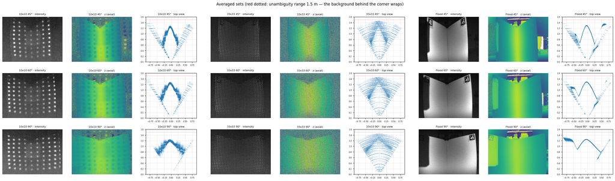

```python
OVERVIEW_ROWS = slice(200, 280)     # rows of the top view


def load_set(pat, angle):
    return dotCal.load_tof_pcd(str(SETS[(pat, angle)]["pcd"]), unit_scale=0.001, depth_mode="axial")


cols = list(PATTERNS) + [FLOOD]
fig, axs = plt.subplots(len(ANGLES), 3 * len(cols), figsize=(3.0 * 3 * len(cols), 2.6 * len(ANGLES)), squeeze=False)
for i, angle in enumerate(ANGLES):
    for j, pat in enumerate(cols):
        t = load_set(pat, angle)
        g, Pm = t["intensity_map"], t["points_map"]
        a0, a1, a2 = axs[i, 3 * j], axs[i, 3 * j + 1], axs[i, 3 * j + 2]
        a0.imshow(g, cmap="gray", vmin=np.nanpercentile(g, 1), vmax=np.nanpercentile(g, 99.7))
        a1.imshow(np.clip(Pm[..., 2], 0, Z_MAX), cmap="viridis")
        band = Pm[OVERVIEW_ROWS].reshape(-1, 3)
        band = band[np.isfinite(band).all(axis=1)]
        a2.scatter(band[:, 0], band[:, 2], s=0.2, lw=0, alpha=0.3)
        a2.set_xlim(-0.9, 0.9); a2.set_ylim(0, 1.6); a2.set_aspect("equal"); a2.grid(alpha=0.3)
        a2.axhline(UNAMBIGUITY, color="r", lw=0.6, ls=":")
        for a, t_ in zip((a0, a1, a2), ("intensity", "z (axial)", "top view")):
            a.set_title(f"{pat} {angle}° · {t_}", fontsize=8)
            a.tick_params(labelsize=6)
        a0.axis("off"); a1.axis("off")
fig.suptitle("Averaged sets (red dotted: unambiguity range 1.5 m — the background behind the corner wraps)", y=1.0)
fig.tight_layout()
plt.show()
```

## Statistical outlier removal (as in the calibration)

The dot calibrations (`…_sor6-0.40_…`) and `iToF_SL_fusion_pipeline.ipynb` filter every ToF cloud with CloudCompare's SOR before the light-path correction and the error model: a point is rejected when the mean distance to its `SOR_K` nearest neighbours exceeds mean + `SOR_NSIGMA`·std over the cloud. The same filter (`sor_keep_mask`, copied from the fusion notebook) runs here on every loaded cloud — dot series and flood — in memory: rejected points become NaN, the files on disk stay untouched. It matters more for single frames than for the 10-frame average.

```python
# ── SOR: CloudCompare statistical outlier removal (iToF_SL_fusion_pipeline.ipynb) ──
from scipy.spatial import cKDTree

SOR_ENABLED = True
SOR_K       = 6       # CloudCompare "points to use for mean distance estimation"
SOR_NSIGMA  = 0.4     # CloudCompare "standard deviation multiplier" (as in the calibrations)
SOR_TAG     = f"_sor{SOR_K}-{SOR_NSIGMA:.2f}" if SOR_ENABLED else ""
SOR_LOG     = {}      # pcd path → (valid, kept)


def sor_keep_mask(xyz, k=None, nsigma=None, z_range=None):
    # CloudCompare's statistical outlier removal (copied from iToF_SL_fusion_pipeline.ipynb).
    # Returns (keep, threshold, n_valid); pixels without a return come back as not-kept.
    k = int(SOR_K if k is None else k)
    nsigma = float(SOR_NSIGMA if nsigma is None else nsigma)
    z_lo, z_hi = DotCalibration.VALID_Z_RANGE if z_range is None else z_range

    xyz = np.asarray(xyz, dtype=np.float64)
    valid = (np.isfinite(xyz).all(axis=1)
             & np.any(xyz != 0.0, axis=1)
             & (xyz[:, 2] >= z_lo) & (xyz[:, 2] <= z_hi))
    keep = np.zeros(len(xyz), dtype=bool)
    idx = np.flatnonzero(valid)
    if idx.size <= k + 1:                      # too few points to say anything
        keep[idx] = True
        return keep, float("inf"), int(idx.size)

    pts = xyz[idx]
    d, _ = cKDTree(pts).query(pts, k=k + 1, workers=1)
    mean_d = d[:, 1:].mean(axis=1)
    thr = float(mean_d.mean() + nsigma * mean_d.std())
    keep[idx] = mean_d <= thr
    return keep, thr, int(idx.size)


def _sor_load_tof_pcd(self, pcd_path, *args, **kwargs):
    t = _sor_inner_load_tof_pcd(self, pcd_path, *args, **kwargs)
    if not SOR_ENABLED:
        return t
    depth_mode = kwargs.get("depth_mode", args[1] if len(args) > 1 else "radial")
    keep, _, n_valid = sor_keep_mask(t["points_3d"])
    P = t["points_3d"].copy()
    P[~keep] = np.nan
    SOR_LOG[str(pcd_path)] = (n_valid, int(keep.sum()))
    t["points_3d"] = P
    t["distance"] = P[:, 2] if depth_mode in ("z", "axial") else np.linalg.norm(P, axis=1)
    if "points_map" in t:
        H, W = t["points_map"].shape[:2]
        t["points_map"] = P.reshape(H, W, 3)
        t["depth_map"] = t["distance"].reshape(H, W)
    return t


_sor_load_tof_pcd._is_sor = True
if not getattr(DotCalibration.load_tof_pcd, "_is_sor", False) and not getattr(DotCalibration.load_tof_pcd, "_is_lpc", False):
    _sor_inner_load_tof_pcd = DotCalibration.load_tof_pcd
    DotCalibration.load_tof_pcd = _sor_load_tof_pcd
print(f"SOR {'ON' if SOR_ENABLED else 'OFF'}: {SOR_K} neighbours, nSigma = {SOR_NSIGMA:.2f}  (tag '{SOR_TAG}')")
```

```
SOR ON: 6 neighbours, nSigma = 0.40  (tag '_sor6-0.40')
```

## ToF light-path correction

As in `MPIsweep.ipynb`: the dot projector (VCSEL 5 / 6) also lights the ToF, from the baseline **B** instead of the lens centre, so the camera reports m = (|P − B| + |P|)/2. The calibrations were made with this correction (`_lpc`), and `tof_light_origin` stores the B they used; the same B corrects the test clouds here: **r = (4m² − |B|²) / (4m − 2 d̂·B)**, P = r·d̂. The flood (VCSEL 4) has no calibration and no known B; its cloud stays uncorrected (see the ground-truth step).

```python
LIGHT_PATH_CORRECTION = True
LPC_TAG     = "_lpc" if LIGHT_PATH_CORRECTION else ""
TOF_LIGHT_B = None            # [m] light source in the PCD frame, set per pattern while loading
TOF_ERR_MODEL = None          # fitted ToF error model (stages 1, 3–6), set per pattern while loading


def correct_light_path(P, B):
    # True points for ToF points P (N, 3) [m] measured with the light source at B.
    P = np.asarray(P, dtype=np.float64)
    B = np.asarray(B, dtype=np.float64)
    with np.errstate(invalid="ignore", divide="ignore"):
        m = np.linalg.norm(P, axis=1)
        d = P / m[:, None]
        r = (4.0 * m * m - B @ B) / (4.0 * m - 2.0 * (d @ B))
    return d * r[:, None]


def _lpc_load_tof_pcd(self, pcd_path, *args, **kwargs):
    # Light-path correction (stage 2), then the fitted error model (stages 1, 3–6) — the same
    # order as in iToF_SL_fusion_pipeline.ipynb.
    t = _lpc_inner_load_tof_pcd(self, pcd_path, *args, **kwargs)
    if TOF_LIGHT_B is None and TOF_ERR_MODEL is None:
        return t
    depth_mode = kwargs.get("depth_mode", args[1] if len(args) > 1 else "radial")
    P = t["points_3d"]
    if TOF_LIGHT_B is not None:
        P = correct_light_path(P, TOF_LIGHT_B)
    H, W = t["points_map"].shape[:2] if "points_map" in t else (None, None)
    P = correct_tof_model(P, H, W)
    t["points_3d"] = P
    t["distance"] = P[:, 2] if depth_mode in ("z", "axial") else np.linalg.norm(P, axis=1)
    if "points_map" in t:
        t["points_map"] = P.reshape(H, W, 3)
        t["depth_map"] = t["distance"].reshape(H, W)
    return t


_lpc_load_tof_pcd._is_lpc = True
if not getattr(DotCalibration.load_tof_pcd, "_is_lpc", False):
    _lpc_inner_load_tof_pcd = DotCalibration.load_tof_pcd
DotCalibration.load_tof_pcd = _lpc_load_tof_pcd

# ── Calibrations ────────────────────────────────────────────────────────────
CALS = {}
for pat, f in CAL_FILES.items():
    cal = approaches.load_calibration(str(f))
    CALS[pat] = cal
    md_ = cal.get("metadata", {})
    B_ = md_.get("tof_light_origin")
    print(f"{pat}: {f.parent.name}\n    created {md_.get('created', '?')[:10]}, "
          f"{sum(t is not None for t in cal['trails'])} trails, mode {cal.get('mode')}, "
          f"B = {np.round(np.asarray(cal['B']) * 1e3, 2).tolist()} mm, "
          f"light origin = {None if B_ is None else np.round(np.asarray(B_) * 1e3, 2).tolist()}")


def light_origin(pat):
    if not LIGHT_PATH_CORRECTION or pat not in CALS:
        return None
    o = CALS[pat].get("metadata", {}).get("tof_light_origin")
    return None if o is None else np.asarray(o, dtype=float)
```

```
10x10: SchmersalReal_paperlike_sor6-0.40_lpc_corr13456_06.10_
    created 2026-10-06, 100 trails, mode y, B = [0.71, -37.65, 32.38] mm, light origin = [0.71, -37.65, 32.38]
33x33: SchmersalRealCoherent_paperlike_sor6-0.40_lpc_corr13456_06.10_CoherentLens
    created 2026-10-06, 1099 trails, mode y, B = [-20.55, -39.44, 14.56] mm, light origin = [-20.55, -39.44, 14.56]
```

## ToF error model (6 correction stages)

`CAL_VARIANT = "corr13456"` uses the calibrations of `iToF_SL_fusion_pipeline.ipynb` with all correction stages on. Those calibrations were made on ToF clouds that had already gone through the error model, so the test clouds here get **the same model** — otherwise B, V, the trails and the test depths would not match:

| Stage | Correction | Physical cause |
| --- | --- | --- |
| 1 | constant offset | zero point / emitter delay |
| 2 | light-path correction (LPC) | light source at B instead of the lens (cell above) |
| 3 | image gradient, constant in mm | effective light origin ≠ B, pixel offsets |
| 4 | image gradient ∝ Z | optical axis of the r→Z conversion |
| 5 | wiggling (periods R/4, R/2, R) | cyclic iToF error, not calibrated for the projector |
| 6 | fixed error per dot | dot-specific residual (organised clouds only) |

`calibration.json` stores only the terms of stages 1, 3–5, not the per-dot bias of stage 6, so the model is refitted here on the same flat-wall data with the code of the fusion notebook (copied verbatim, only `correct_tof_model` takes the model as an argument). The refitted terms are compared with the ones stored in the calibration.

Validity: same processing chain and projector as the wall data — 10x10 ↔ `CalibData_Julian.hdf5`, 33x33 ↔ `CalibData_Julian_LensOnly.hdf5`, exactly the HDF5 files of step 1. Stage 6 only acts where a pixel lies within 3 px of a wall-session dot **and** at a similar inverse depth (|Δw| < 0.1 m⁻¹); in the corner the dots sit at other depths than on the wall, so stage 6 applies only partly. The flood (VCSEL 4) has no wall data and stays uncorrected.

```python
# ── ToF error model: switchable correction stages (fitted on the flat-wall data) ──
# Copied from iToF_SL_fusion_pipeline.ipynb (cell "ToF error model").
import csv
from scipy.spatial import cKDTree

CORR_STAGES = {1: True, 2: True, 3: True, 4: True, 5: True, 6: True}

# Wall measurement per camera (binary2pcd_manual.py output: dots/<d>m.csv) and the B used
# for the LPC while fitting (the pipeline's own LPC iteration keeps estimating B itself).
WALL_SETS = {
    "SchmersalReal": dict(
        root=Path("/home/julian/Documents/Calibrations/RauschmessungManualUnwrapping"),
        exclude=(0.50, 0.55, 0.60, 0.65, 0.70),   # overwritten 01.10 with a coherent dot calibration
        B_ref=[0.73e-3, -39.07e-3, 33.64e-3]),
    "SchmersalRealCoherent": dict(
        root=Path("/home/julian/Documents/Calibrations/RauschmessungManualUnwrappingCoherentLensCalib"),
        exclude=(),
        B_ref=[-20.48e-3, -39.61e-3, 14.68e-3]),
}
CORR_K = (530.7, 530.68, 322.78, 242.17)   # fx, fy, cx, cy of the lens calibration the PCDs use
CORR_MAX_DIST = 2.0      # [m] beyond this the 100 MHz unwrapping fails too often
CORR_GROSS = 0.15        # [m] wrong-k outliers left out of the fit
CORR_DOT_RADIUS = 3.0    # [px] stage 6: pixel ↔ dot assignment radius
CORR_DOT_DW = 0.1        # [1/m] stage 6: inverse-depth tolerance of that assignment
_CORR_R = 299_792_458.0 / (2 * 100e6)       # unambiguity range at 100 MHz
_CORR_W_SCALE = CORR_DOT_RADIUS / CORR_DOT_DW


def _corr_lpc(P, B):
    # Same formula as correct_light_path in the light-path cell (defined further down).
    B = np.asarray(B, dtype=np.float64)
    m = np.linalg.norm(P, axis=1)
    d = P / m[:, None]
    return d * ((4.0 * m * m - B @ B) / (4.0 * m - 2.0 * (d @ B)))[:, None]


def _corr_features(xn, yn, Z, r, stages):
    cols, names = [np.ones_like(Z)], ["offset"]
    if stages[3]:
        cols += [xn, yn]; names += ["grad_x", "grad_y"]
    if stages[4]:
        cols += [xn * Z, yn * Z]; names += ["gradZ_x", "gradZ_y"]
    if stages[5]:
        for T, lab in ((_CORR_R / 4, "R/4"), (_CORR_R / 2, "R/2"), (_CORR_R, "R")):
            cols += [np.sin(2 * np.pi * r / T), np.cos(2 * np.pi * r / T)]
            names += [f"sin {lab}", f"cos {lab}"]
    return np.column_stack(cols), names


def fit_tof_error_model(camera, stages):
    # Fit all enabled stages jointly on the wall dots of `camera`. None if no wall data.
    ws = WALL_SETS.get(camera)
    if ws is None:
        return None
    fxc, fyc, cxc, cyc = CORR_K
    rows = []
    for f in ws["root"].glob("dots/*m.csv"):
        d = float(re.search(r"([\d.]+)m\.csv$", f.name).group(1))
        if d > CORR_MAX_DIST or any(abs(d - e) < 1e-6 for e in ws["exclude"]):
            continue
        for r in csv.DictReader(open(f)):
            if r["valid"] == "1" and r["median_Z_mm"] != "nan":
                rows.append((d, int(r["id"]), float(r["u_sub"]), float(r["v_sub"]),
                             float(r["median_Z_mm"]) * 1e-3))
    D, ids, u, v, Z = (np.array(c) for c in zip(*rows))
    ids = ids.astype(int)
    xn, yn = (u - cxc) / fxc, (v - cyc) / fyc
    P = np.c_[xn * Z, yn * Z, Z]
    if stages[2]:
        P = _corr_lpc(P, ws["B_ref"])
    Zc = P[:, 2]
    e_raw = Z - D
    ok = np.abs(Zc - D) < CORR_GROSS
    F, names = _corr_features(xn, yn, Zc, np.linalg.norm(P, axis=1), stages)
    coef, *_ = np.linalg.lstsq(F[ok], (Zc - D)[ok], rcond=None)
    apply = coef.copy()
    if not stages[1]:
        apply[0] = 0.0                      # offset fitted (keeps the other terms unbiased), not applied
    e_fit = Zc - D - F @ apply
    model = dict(camera=camera, stages=dict(stages), names=names, coef=coef, apply=apply,
                 root=str(ws["root"]), n=int(ok.sum()), n_dots=len(np.unique(ids[ok])))
    if stages[6]:
        res = (Zc - D - F @ coef)[ok]
        dot_bias = {i: float(np.median(res[ids[ok] == i])) for i in np.unique(ids[ok])}
        model["tree"] = cKDTree(np.c_[u[ok], v[ok], _CORR_W_SCALE / D[ok]])
        model["obs_bias"] = np.array([dot_bias[i] for i in ids[ok]])
        e_fit = e_fit - np.where(ok, np.array([dot_bias.get(i, 0.0) for i in ids]), 0.0)
    rms = lambda e: float(np.sqrt(np.mean(e[ok] ** 2)) * 1e3)
    model["rms_before"], model["rms_after"] = rms(e_raw), rms(e_fit)
    return model


def correct_tof_model(P, H=None, W=None, model=None):
    # Subtract the fitted error model from points P (N, 3) [m], along each ray.
    m = TOF_ERR_MODEL if model is None else model
    if m is None:
        return P
    P = np.asarray(P, dtype=np.float64)
    Z = P[:, 2]
    with np.errstate(invalid="ignore", divide="ignore"):
        if H is not None and W is not None and H * W == len(P):
            fxc, fyc, cxc, cyc = CORR_K
            vv, uu = np.mgrid[0:H, 0:W]
            u, v = uu.ravel().astype(float), vv.ravel().astype(float)
            xn, yn = (u - cxc) / fxc, (v - cyc) / fyc
        else:
            u = v = None
            xn, yn = P[:, 0] / Z, P[:, 1] / Z
        F, _ = _corr_features(xn, yn, Z, np.linalg.norm(P, axis=1), m["stages"])
        e = F @ m["apply"]
        if "tree" in m and u is not None:
            good = np.isfinite(Z) & (Z > 0)
            dist, j = m["tree"].query(np.c_[u[good], v[good], _CORR_W_SCALE / Z[good]])
            obs = m["tree"].data[j]
            hit = (np.hypot(obs[:, 0] - u[good], obs[:, 1] - v[good]) < CORR_DOT_RADIUS) \
                & (np.abs(obs[:, 2] - _CORR_W_SCALE / Z[good]) < CORR_DOT_RADIUS)
            e6 = np.zeros(int(good.sum()))
            e6[hit] = m["obs_bias"][j[hit]]
            e[good] += e6
        return P * ((Z - e) / Z)[:, None]


ERR_MODELS = {}
if CAL_VARIANT == "corr13456":
    for pat in PATTERNS:
        m = fit_tof_error_model(ERR_CAMERA[pat], CORR_STAGES)
        ERR_MODELS[pat] = m
        stored = (CALS[pat].get("metadata", {}).get("error_model") or {}).get("terms", {})
        diff = max((abs(m["apply"][i] - stored[n]) for i, n in enumerate(m["names"]) if n in stored),
                   default=np.nan)
        print(f"{pat}: model of {ERR_CAMERA[pat]} from {m['n']} wall-dot measurements ({m['n_dots']} dots), "
              f"wall RMS {m['rms_before']:.1f} → {m['rms_after']:.1f} mm")
        print("    " + "   ".join(f"{n} {c * 1e3:+.2f}" for n, c in zip(m["names"], m["apply"])) + "   [mm]")
        print(f"    max |refit − stored term| = {diff * 1e3:.4f} mm"
              + ("" if diff < 1e-5 else "   WARNING: differs from the model the calibration was made with"))
CORR_TAG = "_corr13456" if ERR_MODELS else ""
print(f"error model {'ON' if ERR_MODELS else 'OFF'} (cache tag '{LPC_TAG}{CORR_TAG}')")
```

```
10x10: model of SchmersalReal from 2534 wall-dot measurements (100 dots), wall RMS 22.5 → 4.8 mm
    offset +6.61   grad_x +16.00   grad_y -3.56   gradZ_x -41.22   gradZ_y +3.89   sin R/4 +3.26   cos R/4 -3.64   sin R/2 -0.95   cos R/2 +0.80   sin R +2.84   cos R -0.90   [mm]
    max |refit − stored term| = 0.0000 mm
```

```
33x33: model of SchmersalRealCoherent from 33767 wall-dot measurements (1097 dots), wall RMS 17.0 → 1.5 mm
    offset +16.90   grad_x -4.07   grad_y +9.19   gradZ_x +14.13   gradZ_y +15.03   sin R/4 +2.87   cos R/4 -3.24   sin R/2 -0.27   cos R/2 -0.67   sin R +0.57   cos R +0.22   [mm]
    max |refit − stored term| = 0.0000 mm
error model ON (cache tag '_lpc_corr13456')
```

## Sweep: Approach 1/2/3 on every corner

|  | depth | pixel |
| --- | --- | --- |
| Approach 1 – consistency error | `Z_out` (ToF at min ε) | `u_out, v_out` |
| Approach 2 – ML fusion | `z_fus` | `u_sub, v_sub` |
| Approach 3 – active brightness | `Z_out` (triangulated) | `u_sub, v_sub` |

X = r_x(u, v)·Z, Y = r_y(u, v)·Z with the lens-model rays of step 1, the same as in the clouds. The flood is the raw iToF cloud (points beyond `Z_MAX` dropped, they are wrapped background). Results are cached in `Results/mpi_sweep_real/` (`<pattern>_<angle>deg_<set>….npz`).

```python
APPROACH_KEYS = {1: ("Z_out", "u_out", "v_out"), 2: ("z_fus", "u_sub", "v_sub"), 3: ("Z_out", "u_sub", "v_sub")}


def to_xyz(results, zkey, ukey, vkey, rays):
    rows = [(r[ukey], r[vkey], r[zkey]) for r in results
            if np.isfinite(r.get(zkey, np.nan)) and np.isfinite(r.get(ukey, np.nan))]
    if not rows:
        return np.zeros((0, 3))
    u, v, z = np.array(rows, float).T
    rx = map_coordinates(rays[0], [v, u], order=1, mode="nearest")
    ry = map_coordinates(rays[1], [v, u], order=1, mode="nearest")
    return np.c_[rx * z, ry * z, z]


def run_dots(pat, angle):
    global TOF_LIGHT_B, TOF_ERR_MODEL
    s = SETS[(pat, angle)]
    cache = CACHE_DIR / f"{pat}_{angle}deg_{s['dir'].name}{FRAME_TAG}{SOR_TAG}{LPC_TAG}{CORR_TAG}.npz"
    if cache.exists() and not FORCE_RERUN:
        with np.load(cache) as f:
            return {a: f[f"A{a}"] for a in (1, 2, 3)} | {"n_trails": int(f["n_trails"])}
    cal = CALS[pat]
    TOF_LIGHT_B = light_origin(pat)               # same corrections as in the calibration
    TOF_ERR_MODEL = ERR_MODELS.get(pat)
    try:
        with contextlib.redirect_stdout(io.StringIO()):
            setup = approaches.common_setup(dotCal, cal, str(s["exr"]), str(s["pcd"]))
            res = {1: approaches.run_approach_1(dotCal, cal, setup, make_plots=False),
                   2: approaches.run_approach_2(dotCal, cal, setup, make_plots=False),
                   3: approaches.run_approach_3(dotCal, cal, setup, make_plots=False)}
    finally:
        TOF_LIGHT_B, TOF_ERR_MODEL = None, None
    out = {a: to_xyz(res[a]["results"], *APPROACH_KEYS[a], RAYS[pat]) for a in (1, 2, 3)}
    out["n_trails"] = sum(t is not None for t in setup["trails"])
    np.savez_compressed(cache, **{f"A{a}": out[a] for a in (1, 2, 3)}, n_trails=out["n_trails"])
    return out


def load_flood(angle):
    # Flood cloud as organised map (H, W, 3) [m], wrapped / invalid points NaN.
    P = load_set(FLOOD, angle)["points_map"].copy()
    P[~(P[..., 2] < Z_MAX)] = np.nan
    return P


RAW = {}        # (angle, series, approach or "ToF") → (N, 3) points, camera frame [m]
N_TRAILS = {}
FLOOD_MAP = {}
for angle in ANGLES:
    for pat in PATTERNS:
        r = run_dots(pat, angle)
        N_TRAILS[pat] = r["n_trails"]
        for a in (1, 2, 3):
            RAW[(angle, pat, a)] = r[a]
        print(f"{angle}° {pat}: valid dots A1/A2/A3 = {len(r[1])}/{len(r[2])}/{len(r[3])} of {r['n_trails']} trails")
    FLOOD_MAP[angle] = load_flood(angle)
    print(f"{angle}° flood: {np.isfinite(FLOOD_MAP[angle][..., 2]).sum()} points")
if SOR_ENABLED:
    print("SOR rejected: " + ", ".join(f"{Path(p).parent.parent.name.split('_', 2)[-1]} "
                                       f"{100 * (1 - k / max(v, 1)):.1f} %" for p, (v, k) in SOR_LOG.items()))
```

```
45° 10x10: valid dots A1/A2/A3 = 97/58/58 of 100 trails
45° 33x33: valid dots A1/A2/A3 = 1062/686/686 of 1099 trails
```

```
45° flood: 266525 points
60° 10x10: valid dots A1/A2/A3 = 94/72/72 of 100 trails
60° 33x33: valid dots A1/A2/A3 = 1083/797/797 of 1099 trails
```

```
60° flood: 272226 points
90° 10x10: valid dots A1/A2/A3 = 97/67/67 of 100 trails
90° 33x33: valid dots A1/A2/A3 = 1080/811/811 of 1099 trails
```

```
90° flood: 277471 points
SOR rejected: Flood_45 11.3 %, Flood_60 9.9 %, Flood_90 8.7 %
```

## Ground truth: one corner per pattern, from its own triangulation

There is no scene file, so the corner is fitted from the data. Every dot pattern measures from its own origin (its projector: 10x10 ≈ 28 mm in front of the flood, 33x33 ≈ level with it) and with its own calibration, so every pattern gets **its own** ground truth:

1. **Flood walls (frame and region only):** the fold column is the column with the largest median depth in the central rows (searched in the image centre). RANSAC planes (inliers < `RANSAC_THR`) to the flood pixels left and right of the fold, from `FOLD_MARGIN` (measured along the wall) up to `WALL_WIDTH_PX` columns away. They define the region of interest and the start of the wall split.
2. **GT per pattern:** RANSAC planes to the pattern's own **Approach-3** points (triangulation — no ToF depth, so hardly touched by multipath) farther than the margin from the fold. 10x10 A1/A2/A3 are evaluated against the 10x10 corner, 33x33 A1/A2/A3 against the 33x33 corner, and the **flood against the 33x33 corner** (same height). Each series is shown in the corner frame of its GT: y along the fold, z from the camera to the fold, x across; the fold sits at (0, d).
3. **Walls end at `WALL_LENGTH`** = 0.69 m from the fold (the real wall), so RMSE refers to the target.
4. **Region of interest** = an image region: the pixels whose flood point lies on its wall, within the y band ≤ ±`Y_HALF`, the x range up to the wall edges / image border and at most `WALL_LENGTH` from the fold. Every point of every series is assigned to its pixel by its ray direction and kept if that pixel is in the region.

```python
WALL_LENGTH     = 0.69    # [m] fold → outer edge, horizontal (0.68–0.70 m); GT walls end there
RANSAC_THR      = 0.015   # [m]
FOLD_MARGIN     = 0.15    # [m] wall points used for the fits keep this distance to the fold, measured
                          # ALONG the wall (laterally: FOLD_MARGIN·sin(inner/2), so narrow corners keep wall left)
FOLD_SEARCH_U   = (220, 420)   # [px] columns searched for the fold
WALL_WIDTH_PX   = 170     # [px] wall band used for the flood fit, beyond the margin
FIT_ROWS        = slice(120, 360)
MIN_WALL_POINTS = 10
Y_HALF          = 0.40    # [m] max. half height of the evaluated band on the walls
ROI_TOL         = 0.05    # [m] a flood point "lies on the wall" within this distance
_rng_fit = np.random.default_rng(1)


def fit_plane(P):
    c = P.mean(axis=0)
    n = np.linalg.svd(P - c, full_matrices=False)[2][2]
    d = -n @ c
    return (n, d) if d > 0 else (-n, -d)          # normal towards the camera (origin on + side)


def ransac_plane(P, thr=RANSAC_THR, iters=400):
    best = None
    for _ in range(iters):
        p = P[_rng_fit.choice(len(P), 3, replace=False)]
        n = np.cross(p[1] - p[0], p[2] - p[0])
        if np.linalg.norm(n) < 1e-12:
            continue
        n /= np.linalg.norm(n)
        inl = np.abs((P - p[0]) @ n) < thr
        if best is None or inl.sum() > best.sum():
            best = inl
    for _ in range(2):
        n, d = fit_plane(P[best])
        best = np.abs(P @ n + d) < thr
    return n, d, best


def flood_walls(Pmap, margin_x):
    zc = np.nanmedian(Pmap[FIT_ROWS, :, 2], axis=0)
    zc_s = np.convolve(np.nan_to_num(zc), np.ones(9) / 9, mode="same")
    u_fold = FOLD_SEARCH_U[0] + int(np.argmax(zc_s[FOLD_SEARCH_U[0]:FOLD_SEARCH_U[1]]))
    margin_px = margin_x * 495.0 / zc_s[u_fold]
    band = Pmap[FIT_ROWS]
    u = np.broadcast_to(np.arange(band.shape[1]), band.shape[:2])
    ok = np.isfinite(band).all(axis=-1)
    walls, share = [], []
    for side in ((u < u_fold - margin_px) & (u > u_fold - margin_px - WALL_WIDTH_PX),
                 (u > u_fold + margin_px) & (u < u_fold + margin_px + WALL_WIDTH_PX)):
        n, d, inl = ransac_plane(band[ok & side])
        walls.append((n, d))
        share.append(inl.mean())
    return walls, u_fold, share


def ray_range_to_corner(P, walls):
    # Range along the ray of every point P to the (concave) corner = nearer wall intersection.
    dh = P / np.linalg.norm(P, axis=1, keepdims=True)
    t = np.stack([-d / (dh @ n) for n, d in walls], axis=1)
    t[t <= 0] = np.inf
    return t.min(axis=1)


def corner_frame(walls):
    (n1, d1), (n2, d2) = walls
    ey = np.cross(n1, n2); ey /= np.linalg.norm(ey)
    if ey[1] < 0:
        ey = -ey
    O = np.linalg.solve(np.array([n1, n2, ey]), np.array([-d1, -d2, 0.0]))   # fold point nearest the camera
    ez = O - (O @ ey) * ey; ez /= np.linalg.norm(ez)
    ex = np.cross(ey, ez)
    if ex[0] < 0:
        ex = -ex
    R = np.stack([ex, ey, ez])
    dist = float(np.linalg.norm(O))
    shift = np.array([0.0, 0.0, dist])
    to_corner = lambda P: (np.asarray(P) - O) @ R.T + shift
    return dict(to_corner=to_corner, R=R, O=O, dist=dist, walls=walls,
                corner=corner_polyline(walls, R, O, shift))


def corner_polyline(walls, R, O, shift):
    # Walls (camera frame) → top-view polyline [(x_left, z_left), (x_fold, z_fold), (x_right, z_right)]
    # in the corner frame, each wall running WALL_LENGTH from the fold towards the camera.
    lines = []
    for n, d in walls:
        nc = R @ n
        lines.append((nc[0], nc[2], d + n @ O - nc @ shift))      # a·x + b·z + c = 0  (y = 0)
    (a1, b1, c1), (a2, b2, c2) = lines
    xf, zf = np.linalg.solve([[a1, b1], [a2, b2]], [-c1, -c2])
    ends = []
    for a, b, _ in lines:
        t = np.array([b, -a]) / np.hypot(a, b)                       # direction along the wall
        t = t if t[1] < 0 else -t                                     # … towards the camera
        ends.append((xf + WALL_LENGTH * t[0], zf + WALL_LENGTH * t[1]))
    c = np.array([ends[0], [xf, zf], ends[1]])
    return c[np.argsort(c[:, 0])]


def inner_angle(corner):
    v = [(c - corner[1]) / np.linalg.norm(c - corner[1]) for c in corner[[0, 2]]]
    return float(np.degrees(np.arccos(np.clip(v[0] @ v[1], -1, 1))))


def z_gt(x, corner):
    # GT depth of the corner at lateral position x (single-valued over the corner width).
    return np.interp(x, corner[:, 0], corner[:, 1], left=np.nan, right=np.nan)


def dist_to_gt(x, z, corner):
    # Perpendicular distance [m] of points (x, z) to the nearer of the two walls.
    pts = np.c_[x, z]
    best = np.full(len(pts), np.inf)
    for a, b in ((corner[0], corner[1]), (corner[1], corner[2])):
        ab = b - a
        t = np.clip(((pts - a) @ ab) / (ab @ ab), 0, 1)
        best = np.minimum(best, np.linalg.norm(pts - (a + t[:, None] * ab), axis=1))
    return best


def lateral_margin(corner):
    # FOLD_MARGIN along the wall → lateral distance from the fold.
    return FOLD_MARGIN * np.sin(np.radians(inner_angle(corner) / 2))


GT = {}          # flood walls per angle: frame for the region of interest
for angle in ANGLES:
    mx = FOLD_MARGIN * np.sin(np.radians(angle / 2))          # start from the nominal angle …
    for _ in range(3):                                         # … then from the fitted one
        walls, u_fold, share = flood_walls(FLOOD_MAP[angle], mx)
        GT[angle] = corner_frame(walls)
        mx = lateral_margin(GT[angle]["corner"])
    GT[angle].update(mx=mx, u_fold=u_fold)
    print(f"{angle}° flood walls: fold column {u_fold}, fold at d = {GT[angle]['dist']:.3f} m, inner angle "
          f"{inner_angle(GT[angle]['corner']):.1f}°  (RANSAC inliers {share[0]:.0%} / {share[1]:.0%}, "
          f"lateral margin {mx * 100:.1f} cm)")
```

```
45° flood walls: fold column 312, fold at d = 1.433 m, inner angle 37.9°  (RANSAC inliers 97% / 98%, lateral margin 4.9 cm)
```

```
60° flood walls: fold column 311, fold at d = 1.404 m, inner angle 51.3°  (RANSAC inliers 98% / 97%, lateral margin 6.5 cm)
```

```
90° flood walls: fold column 304, fold at d = 1.317 m, inner angle 80.5°  (RANSAC inliers 94% / 99%, lateral margin 9.7 cm)
```

```python
# ── GT per pattern: walls from the pattern's own triangulated (A3) points ──
FOLD_DISTANCE = {"MPI_1m_WW": 1.03}   # [m] tape-measured camera–fold distance (information only)
GT_OF = {"10x10": "10x10", "33x33": "33x33", FLOOD: "33x33"}   # which pattern's corner a series uses


def series_walls(P_cam, frame):
    # Two walls from one series: RANSAC per side on its points far from the fold (None if too few).
    Pc = frame["to_corner"](P_cam)
    walls = []
    for side in (Pc[:, 0] < -frame["mx"], Pc[:, 0] > frame["mx"]):
        if side.sum() < MIN_WALL_POINTS:
            return None, f"{side.sum()} wall points"
        n, d, _ = ransac_plane(P_cam[side], thr=max(RANSAC_THR, 0.02), iters=400)
        walls.append((n, d))
    return walls, ""


def fit_shape(P_cam, frame):
    # Walls from P_cam, the margin iterated with the walls' own frame.
    for _ in range(3):
        walls, why = series_walls(P_cam, frame)
        if walls is None:
            return None, why
        frame = corner_frame(walls)
        frame["mx"] = lateral_margin(frame["corner"])
    return walls, ""


PGT = {}
tape = FOLD_DISTANCE.get(MEAS_ROOT.name)
print("GT per pattern (A3 walls): fold distance d and inner angle"
      + (f"  — tape-measured fold distance {tape:.3f} m" if tape else ""))
for angle in ANGLES:
    row = []
    for pat in PATTERNS:
        w, why = fit_shape(RAW[(angle, pat, 3)], GT[angle])
        if w is None:
            print(f"  {angle}° {pat}: A3 gives no walls ({why}) — flood walls used")
            w = GT[angle]["walls"]
        fr = corner_frame(w)
        fr["mx"] = lateral_margin(fr["corner"])
        PGT[(angle, pat)] = fr
        row.append(f"{pat} d = {fr['dist']:.3f} m, {inner_angle(fr['corner']):5.1f}°")
    row.append(f"flood walls d = {GT[angle]['dist']:.3f} m, {inner_angle(GT[angle]['corner']):5.1f}°")
    print(f"  {angle}°: " + "   |   ".join(row))
```

```
GT per pattern (A3 walls): fold distance d and inner angle
  45°: 10x10 d = 1.287 m,  38.9°   |   33x33 d = 1.412 m,  37.3°   |   flood walls d = 1.433 m,  37.9°
```

```
  60°: 10x10 d = 1.295 m,  51.7°   |   33x33 d = 1.403 m,  51.2°   |   flood walls d = 1.404 m,  51.3°
  90°: 10x10 d = 1.283 m,  79.1°   |   33x33 d = 1.402 m,  77.5°   |   flood walls d = 1.317 m,  80.5°
```

```python
# ── Region of interest (image region) and the evaluation frame ──────────────
from scipy.spatial import cKDTree as _KD


def gt_hit(P, frame):
    # Where the pixel ray of every point hits the corner of `frame` (corner coordinates).
    P = np.asarray(P, float)
    rh = P / np.linalg.norm(P, axis=1, keepdims=True)
    return frame["to_corner"](rh * ray_range_to_corner(P, frame["walls"])[:, None])


def runs_from(good, start, step):
    # Outer end of the run of good bins that starts at the first good bin from `start` on.
    k = start
    while 0 <= k < len(good) and not good[k]:
        k += step
    if not (0 <= k < len(good)):
        return start
    while 0 <= k + step < len(good) and good[k + step]:
        k += step
    return k


def roi_limits(fl, frame):
    Q = gt_hit(fl, frame)
    flc = frame["to_corner"](fl)
    on_wall = dist_to_gt(flc[:, 0], flc[:, 2], frame["corner"]) < ROI_TOL
    mx = frame["mx"]
    # vertical: bins in y on the walls (mx < |x| < 2·mx), contiguous around 0
    e = np.arange(-Y_HALF, Y_HALF + 1e-9, 0.02)
    sel = (np.abs(Q[:, 0]) > mx) & (np.abs(Q[:, 0]) < 2 * mx)
    idx = np.digitize(Q[sel, 1], e) - 1
    good = np.array([(idx == k).sum() > 30 and on_wall[sel][idx == k].mean() > 0.8 for k in range(len(e) - 1)])
    k0 = len(good) // 2
    y_lim = (e[runs_from(good, k0, -1)], e[runs_from(good, k0 - 1, +1) + 1])
    # lateral: on each side, the run of good bins from the margin outwards
    e = np.arange(-1.2, 1.2001, 0.01)
    sel = (Q[:, 1] >= y_lim[0]) & (Q[:, 1] <= y_lim[1])
    idx = np.digitize(Q[sel, 0], e) - 1
    good = np.array([(idx == k).sum() > 30 and on_wall[sel][idx == k].mean() > 0.8 for k in range(len(e) - 1)])
    kl = int(np.searchsorted(e, -mx)) - 1
    kr = int(np.searchsorted(e, mx))
    x_lim = (e[runs_from(good, kl, -1)], e[runs_from(good, kr, +1) + 1])
    cap = WALL_LENGTH * np.sin(np.radians(inner_angle(frame["corner"]) / 2))   # walls end at WALL_LENGTH
    return (max(x_lim[0], -cap), min(x_lim[1], cap)), y_lim


# Pixel of a point = the lens ray closest to its direction.
_rx, _ry = RAYS[FLOOD]
_RAY_TREE = _KD(np.c_[_rx.ravel(), _ry.ravel()])


def pixel_of(P):
    P = np.asarray(P, float)
    return _RAY_TREE.query(np.c_[P[:, 0] / P[:, 2], P[:, 1] / P[:, 2]])[1]


SWEEP, CORNERS, ROI, ROI_MASK, N_ROI, EVAL, FRAME_OF = {}, {}, {}, {}, {}, {}, {}
for angle in ANGLES:
    g = GT[angle]
    Pm = FLOOD_MAP[angle]
    flat = Pm.reshape(-1, 3)
    ok = np.isfinite(flat).all(axis=1)
    ROI[angle] = roi_limits(flat[ok], g)
    (x0, x1), (y0, y1) = ROI[angle]
    mask = np.zeros(len(flat), bool)
    Q = gt_hit(flat[ok], g)
    mask[np.flatnonzero(ok)] = (Q[:, 0] >= x0) & (Q[:, 0] <= x1) & (Q[:, 1] >= y0) & (Q[:, 1] <= y1)
    ROI_MASK[angle] = mask.reshape(Pm.shape[:2])
    N_ROI[angle] = int(mask.sum())
    EVAL[angle] = PGT[(angle, "33x33")]            # axes / labels of the plots

    series_pts = {(FLOOD, "ToF"): flat[mask]}
    for pat in PATTERNS:
        for a in (1, 2, 3):
            P = RAW[(angle, pat, a)]
            series_pts[(pat, a)] = P[mask[pixel_of(P)]] if len(P) else np.zeros((0, 3))
    for (series, a), P in series_pts.items():
        fr = PGT[(angle, GT_OF[series])]
        FRAME_OF[(angle, series, a)] = fr
        SWEEP[(angle, series, a)] = fr["to_corner"](P) if len(P) else np.zeros((0, 3))
        CORNERS[(angle, series, a)] = fr["corner"]
    print(f"{angle}°: ROI {N_ROI[angle]} pixels (on the flood walls x = {x0:+.2f} … {x1:+.2f} m, "
          f"y = {y0:+.2f} … {y1:+.2f} m); in ROI A1/A2/A3: "
          + ", ".join(f"{p} " + "/".join(str(len(SWEEP[(angle, p, a)])) for a in (1, 2, 3)) for p in PATTERNS)
          + f", flood {len(SWEEP[(angle, FLOOD, 'ToF')])}")

print("\nGT wall range along the ray − point range, points farther than the margin from the fold "
      "(median ± MAD [mm]; + = point in front of its GT). A3 ≈ 0 by construction; A1/A2 and the flood "
      "show their offset to the triangulation of their pattern:")
for angle in ANGLES:
    row = []
    for series, a in [(p, a) for p in PATTERNS for a in (1, 2, 3)] + [(FLOOD, "ToF")]:
        fr = FRAME_OF[(angle, series, a)]
        Pc = SWEEP[(angle, series, a)]
        P = (Pc - np.array([0.0, 0.0, fr["dist"]])) @ fr["R"] + fr["O"]          # back to the camera frame
        far = np.abs(Pc[:, 0]) > fr["mx"]
        dd = ray_range_to_corner(P[far], fr["walls"]) - np.linalg.norm(P[far], axis=1)
        dd = dd[np.isfinite(dd)]
        lab = f"{series} {'A' + str(a) if a != 'ToF' else 'ToF'}"
        row.append(f"{lab} {np.median(dd) * 1e3:+6.1f}±{np.median(np.abs(dd - np.median(dd))) * 1e3:4.1f}"
                   if len(dd) else f"{lab} –")
    print(f"  {angle}°: " + " | ".join(row[:3]) + "\n        " + " | ".join(row[3:6]) + "\n        " + row[6])
```

```
45°: ROI 101307 pixels (on the flood walls x = -0.22 … +0.22 m, y = -0.28 … +0.40 m); in ROI A1/A2/A3: 10x10 37/37/37, 33x33 433/422/422, flood 101307
60°: ROI 132840 pixels (on the flood walls x = -0.30 … +0.30 m, y = -0.28 … +0.40 m); in ROI A1/A2/A3: 10x10 52/51/51, 33x33 567/557/557, flood 132840
```

```
90°: ROI 152760 pixels (on the flood walls x = -0.34 … +0.45 m, y = -0.28 … +0.40 m); in ROI A1/A2/A3: 10x10 60/57/57, 33x33 636/624/624, flood 152760

GT wall range along the ray − point range, points farther than the margin from the fold (median ± MAD [mm]; + = point in front of its GT). A3 ≈ 0 by construction; A1/A2 and the flood show their offset to the triangulation of their pattern:
  45°: 10x10 A1   -7.7±12.4 | 10x10 A2   -7.0±10.9 | 10x10 A3   -1.6±10.3
        33x33 A1   +4.0±28.0 | 33x33 A2   +1.7± 7.7 | 33x33 A3   +0.5± 8.5
        Flood ToF  -17.1±23.3
  60°: 10x10 A1   -6.3± 6.3 | 10x10 A2   -4.6± 6.2 | 10x10 A3   -0.8± 9.4
        33x33 A1  +12.5±23.2 | 33x33 A2   +0.4± 8.2 | 33x33 A3   -1.1± 8.0
        Flood ToF   +1.1±21.3
  90°: 10x10 A1  +17.0± 7.4 | 10x10 A2  +15.5± 6.2 | 10x10 A3   -0.8± 9.8
        33x33 A1  +44.1±31.8 | 33x33 A2   +3.6± 9.6 | 33x33 A3   +0.2±10.1
        Flood ToF  +44.4±23.4
```

## Results — plot functions

The plots of `MPIsweep.ipynb`, with the corner angle in place of the distance (one row per corner):

```python
# Okabe–Ito, same assignment as noiseEstimation.ipynb / MPIsweep.ipynb.
A_COLOR = {1: "#0072B2", 2: "#D55E00", 3: "#009E73", "ToF": "#000000"}
A_NAME = {1: "A1 consistency", 2: "A2 ML fusion", 3: "A3 active brightness", "ToF": "iToF only"}
COLUMNS = [(pat, a) for pat in PATTERNS for a in (1, 2, 3)] + [(FLOOD, "ToF")]
COL_LABEL = {**{(pat, a): f"{PATTERNS[pat]['label']} · {A_NAME[a]}" for pat in PATTERNS for a in (1, 2, 3)},
             (FLOOD, "ToF"): "Flood · iToF only"}
FLOOD_PLOT_MAX = 20000        # flood points drawn per panel (random subset)
PROFILE_YLIM = 0.06           # ±[m]
TOPVIEW_Z_EXTRA = {("MPI_1m_WW", 60, "33x33"): 0.08}   # [m] extra headroom above (folder, angle, pattern)
FOLD_HALF_WIDTH = 0.05        # [m]
_rng = np.random.default_rng(0)


def series_stats(angle, series, a):
    pts = SWEEP[(angle, series, a)]
    if len(pts) == 0:
        return pts, np.nan
    err = dist_to_gt(pts[:, 0], pts[:, 2], CORNERS[(angle, series, a)])
    return pts, float(np.sqrt(np.mean(err ** 2)))


def view_limits(angle):
    fl = SWEEP[(angle, FLOOD, "ToF")]
    d = EVAL[angle]["dist"]
    # upper limit: fold, flood and every dot series of the row (99.5th percentile, ignores single outliers)
    z_top = [float(np.percentile(SWEEP[(angle, s, a)][:, 2], 99.5)) for s, a in COLUMNS if len(SWEEP[(angle, s, a)])]
    z_hi = max([d] + z_top) + 0.05
    return (fl[:, 0].min() - 0.05, fl[:, 0].max() + 0.05), (fl[:, 2].min() - 0.05, z_hi)


def plot_topview():
    fig, axs = plt.subplots(len(ANGLES), len(COLUMNS), figsize=(3.1 * len(COLUMNS), 2.9 * len(ANGLES)),
                            squeeze=False)
    for i, angle in enumerate(ANGLES):
        xlim, zlim = view_limits(angle)
        for j, (series, a) in enumerate(COLUMNS):
            ax = axs[i, j]
            pts, rmse = series_stats(angle, series, a)
            if series == FLOOD and len(pts) > FLOOD_PLOT_MAX:
                pts = pts[_rng.choice(len(pts), FLOOD_PLOT_MAX, replace=False)]
            ax.scatter(pts[:, 0], pts[:, 2], s=1.5 if series == FLOOD else 5, lw=0,
                       c=A_COLOR[a], alpha=0.25 if series == FLOOD else 0.8)
            c = CORNERS[(angle, series, a)]
            ax.plot(c[:, 0], c[:, 1], "k-", lw=1.2)
            extra = TOPVIEW_Z_EXTRA.get((MEAS_ROOT.name, angle, series), 0.0)
            ax.set_xlim(xlim); ax.set_ylim(zlim[0], zlim[1] + extra)
            ax.set_aspect("equal", adjustable="datalim")   # true angles: same scale in x and z
            if extra:
                ax.apply_aspect()                           # datalim may trim z again — keep the headroom
                lo, hi = ax.get_ylim()
                if hi < zlim[1] + extra:
                    ax.set_ylim(lo + (zlim[1] + extra - hi), zlim[1] + extra)
            ax.set_title(f"RMSE {rmse * 1e3:.1f} mm · n={len(SWEEP[(angle, series, a)])}", fontsize=8)
            ax.tick_params(labelsize=7)
            ax.grid(alpha=0.25, lw=0.5)
            if i == 0:
                ax.annotate(COL_LABEL[(series, a)], (0.5, 1.25), xycoords="axes fraction",
                            ha="center", fontsize=9, fontweight="bold")
            if j == 0:
                ax.set_ylabel(f"{angle}° (GT {inner_angle(EVAL[angle]['corner']):.0f}°)\nz [m]", fontsize=9)
            if i == len(ANGLES) - 1:
                ax.set_xlabel("x [m]", fontsize=8)
    fig.suptitle(f"Real corners · top view (x–z, corner frame) · black: ground truth of each pattern (flood: 33x33)", y=1.0, fontsize=13)
    fig.tight_layout()
    plt.show()


def plot_profile():
    fig, axs = plt.subplots(len(ANGLES), len(COLUMNS), figsize=(3.1 * len(COLUMNS), 2.4 * len(ANGLES)),
                            squeeze=False, sharey=True)
    for i, angle in enumerate(ANGLES):
        xlim, _ = view_limits(angle)
        for j, (series, a) in enumerate(COLUMNS):
            ax = axs[i, j]
            c = CORNERS[(angle, series, a)]
            pts = SWEEP[(angle, series, a)]
            x_rel = pts[:, 0] - c[1, 0]
            dz = pts[:, 2] - z_gt(pts[:, 0], c)
            if series == FLOOD:
                sub = _rng.choice(len(pts), min(len(pts), FLOOD_PLOT_MAX), replace=False)
                ax.scatter(x_rel[sub], dz[sub], s=1, lw=0, c="0.6", alpha=0.3)
                bins = np.arange(x_rel.min(), x_rel.max() + 0.01, 0.01)
                idx = np.digitize(x_rel, bins)
                med = [np.nanmedian(dz[idx == k]) if np.sum(np.isfinite(dz[idx == k])) > 20 else np.nan
                       for k in range(1, len(bins))]
                ax.plot(bins[:-1] + 0.005, med, "k-", lw=1.5)
            else:
                ax.scatter(x_rel, dz, s=6, lw=0, c=A_COLOR[a], alpha=0.85)
            ax.axhline(0, color="k", lw=0.8)
            ax.axvline(0, color="k", lw=0.6, ls=":")
            ax.set_ylim(-PROFILE_YLIM, PROFILE_YLIM)
            ax.set_xlim(xlim[0] - c[1, 0], xlim[1] - c[1, 0])
            ax.tick_params(labelsize=7)
            ax.grid(alpha=0.25, lw=0.5)
            if i == 0:
                ax.annotate(COL_LABEL[(series, a)], (0.5, 1.12), xycoords="axes fraction",
                            ha="center", fontsize=9, fontweight="bold")
            if j == 0:
                ax.set_ylabel(f"{angle}°\nz − z_GT [m]", fontsize=9)
            if i == len(ANGLES) - 1:
                ax.set_xlabel("x − x_fold [m]", fontsize=8)
    fig.suptitle("Real corners · depth error across the fold (dotted: fold position)", y=1.0, fontsize=13)
    fig.tight_layout()
    plt.show()


def plot_summary():
    rows = []
    for series, a in COLUMNS:
        for angle in ANGLES:
            pts, rmse = series_stats(angle, series, a)
            c = CORNERS[(angle, series, a)]
            near = np.abs(pts[:, 0] - c[1, 0]) < FOLD_HALF_WIDTH if len(pts) else np.zeros(0, bool)
            fold_err = float(np.mean(pts[near, 2] - z_gt(pts[near, 0], c))) if near.any() else np.nan
            n_ref = N_TRAILS.get(series) or N_ROI[angle]
            rows.append((series, a, angle, rmse, fold_err, len(pts) / n_ref, int(near.sum())))
    rows_arr = np.array([(r[2], r[3], r[4], r[5]) for r in rows], float)

    fig, axs = plt.subplots(1, 3, figsize=(17, 4.6))
    for series, a in COLUMNS:
        sel = [k for k, r in enumerate(rows) if r[0] == series and r[1] == a]
        ls = "--" if series == "33x33" else "-"
        lw = 2.4 if series == FLOOD else 1.7
        for ax, col, scale in zip(axs, (1, 2, 3), (1e3, 1e3, 100)):
            ax.plot(rows_arr[sel, 0], rows_arr[sel, col] * scale, ls, color=A_COLOR[a], lw=lw,
                    marker="o", ms=4, label=COL_LABEL[(series, a)])
    axs[0].set_ylabel("RMSE to GT walls [mm]")
    axs[1].set_ylabel(f"mean z − z_GT, |x − x_fold| < {FOLD_HALF_WIDTH * 100:.0f} cm [mm]")
    axs[1].axhline(0, color="k", lw=0.8)
    axs[2].set_ylabel("valid [% of trails / ROI pixels]")
    for ax, t in zip(axs, ("(a) accuracy", "(b) fold error (multipath bump)", "(c) coverage")):
        ax.set_xlabel("inner corner angle [deg]")
        ax.set_xticks(ANGLES)
        ax.set_title(t)
        ax.grid(alpha=0.3)
    axs[2].legend(fontsize=7, loc="center left", bbox_to_anchor=(1.02, 0.5))
    fig.suptitle("Real corners · summary over the corner angle", fontsize=13)
    fig.tight_layout()
    plt.show()

    print(f"{'series':28s}" + "".join(f"{a:>8d}°" for a in ANGLES) + "   (RMSE [mm] / fold error [mm])")
    for series, a in COLUMNS:
        sel = [r for r in rows if r[0] == series and r[1] == a]
        print(f"{COL_LABEL[(series, a)]:28s}" + "".join(f"{r[3] * 1e3:9.1f}" for r in sel))
        print(f"{'':28s}" + "".join(f"{r[4] * 1e3:+9.1f}" for r in sel))
```

## Results

One row per corner, from the narrowest (strongest interreflection) to the widest (90°, the `MPI_45deg` corner of the simulation). Every series is compared with the corner of its own pattern (flood: 33x33), so a constant offset of a whole A1/A2/flood column is the ToF offset to the triangulation (table "GT wall − point range" above), and the change towards the fold is the multipath.

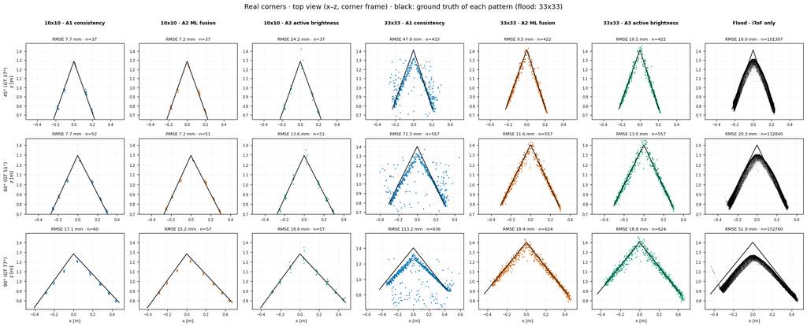

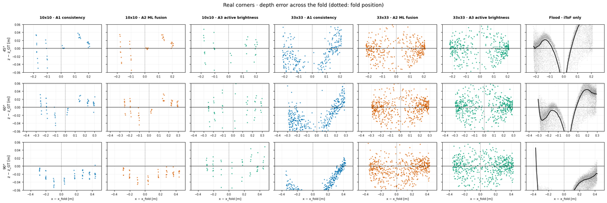

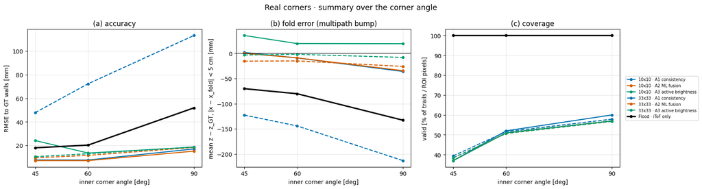

```
series                            45°      60°      90°   (RMSE [mm] / fold error [mm])
10x10 · A1 consistency            7.7      7.7     17.1
                                 +1.8     -9.2    -36.0
10x10 · A2 ML fusion              7.2      7.2     15.2
                                 -0.0     -9.0    -34.4
10x10 · A3 active brightness     24.2     13.6     18.6
                                +35.5    +19.4    +19.1
33x33 · A1 consistency           47.8     72.3    113.2
                               -122.6   -144.3   -213.2
33x33 · A2 ML fusion              9.5     11.6     18.4
                                -15.6    -15.1    -26.0
33x33 · A3 active brightness     10.5     13.0     18.8
                                 -3.3     -1.9     -8.1
Flood · iToF only                18.0     20.3     51.9
                                -70.2    -80.3   -132.9
```

```python
plot_topview()
plot_profile()
plot_summary()
```

## Export for `MPI_flood_reflectivity.ipynb`

The flood clouds (after SOR), the region of interest, the flood walls and the 33x33 corner of every angle are written to `Results/mpi_sweep_real/flood_export_<folder>.pkl`, so the reflectivity fit of the simulation can work on exactly the clouds evaluated here without rerunning the sweep.

```python
import pickle
FLOOD_EXPORT = CACHE_DIR / f"flood_export_{MEAS_ROOT.name}.pkl"
with open(FLOOD_EXPORT, "wb") as f:
    pickle.dump(dict(
        meas_root=str(MEAS_ROOT), frame_mode=FRAME_MODE, sor=SOR_TAG, angles=list(ANGLES),
        tape=FOLD_DISTANCE.get(MEAS_ROOT.name),
        flood={a: FLOOD_MAP[a] for a in ANGLES},
        roi={a: tuple(map(tuple, ROI[a])) for a in ANGLES},
        u_fold={a: GT[a]["u_fold"] for a in ANGLES},
        flood_walls={a: [(n.tolist(), float(d)) for n, d in GT[a]["walls"]] for a in ANGLES},
        walls_33x33={a: [(n.tolist(), float(d)) for n, d in PGT[(a, "33x33")]["walls"]] for a in ANGLES},
        walls_10x10={a: [(n.tolist(), float(d)) for n, d in PGT[(a, "10x10")]["walls"]] for a in ANGLES},
    ), f)
print(f"flood export → {FLOOD_EXPORT}")
```

```
flood export → /home/julian/Documents/Github/iToF-SL-Combination/Results/mpi_sweep_real/flood_export_MPI_Messung_07.10.pkl
```

## Notes

- Data: AandB, 100 MHz. `FRAME_MODE = "first"` (default) evaluates the first RAW frame of every set (`ToF_PCD/<frame>.pcd`, `SL/<frame>.exr` next to the RAWs); `"avg"` averages the 10 frames tap by tap (`process_2rad(Diffs=…)` keeps the sub-LSB part) into `avg.pcd` / `avg.exr`.
- Depth calibration: 10x10 and flood with `CalibData_Julian.hdf5`, 33x33 with `CalibData_Julian_LensOnly.hdf5` — the combinations that reproduce the calibration PCDs of 25.08 (10x10, delay 7/0/5) and 30.09 (33x33, delay 0/0/0) to ~1 cm. With the other file the range is off by ≈ 0.18 m.
- Dot calibrations are the existing ones, selected by `CAL_VARIANT`: `corr13456` (6-stage ToF error model, refitted here and applied to the test clouds) or `lpc` (light-path correction only). Like the calibrations, every test cloud is SOR-filtered (6 neighbours, 0.4 σ) before the light-path correction and the error model. The 10x10 calibration data dates from 25.08.
- The flood (VCSEL 4) has no calibration of its own: no light-path correction, and its absolute range carries an unknown constant offset. The two dot calibrations also disagree on the absolute depth (table in the ground-truth step).
- Ground truth: one corner per pattern from its own Approach-3 (triangulated) points far from the fold; the flood is compared with the 33x33 corner. The pattern origins differ (10x10 projector ≈ 28 mm in front of the flood, 33x33 ≈ level), and so do the calibrations: at 1 m (tape: 1.03 m) the 10x10 triangulation puts the fold at ≈ 1.07 m, the 33x33 at ≈ 1.17 m.
- 100 MHz → unambiguous up to 1.5 m. The background behind the corner wraps; everything beyond `Z_MAX` and outside the ROI is dropped. The folds lie at ≈ 1.3–1.5 m, so the indirect paths of the interreflection are longer than 1.5 m and wrap as well: their phasors pull the mixed phase towards *shorter* ranges. The flood corner is therefore rounded towards the camera here, unlike a multipath bulge that stays within the unambiguity range.
- The approaches' global settings (`EPS_THRESHOLD`, peak finding, …) are the defaults of `approaches.py`, unchanged.